# Performance of prediction models for opportunities for improvment in trauma care among women compared to men and across patient cohorts

Anna Thoss

## Introduction

Trauma, defined as the clinical entity composed of the combination of physical injury and the body’s associated responses (1) is a significant public health concern worldwide, accounting for a substantial portion of morbidity and mortality rates, being the cause of 4.3 million fatalities each year (2). Trauma, and care of patients with traumatic injuries, has long been a significant target point for healthcare improvement programs (3). Multidisciplinary morbidity and mortality conferences form the cornerstone of initiatives dedicated to enhancing the quality of trauma care and consequently, improving patient outcomes (4).

At mortality and morbidity conferences, representatives from different professions and specialties adjacent to trauma care come together to discuss care provided to a specific patient and compare it to care given under optimal conditions. The findings of such a conference are whether OFI can be found in any given case. Examples of OFI may include lack of resources and management errors (6).

To enhance the precision of the selection process, there have been efforts to introduce trauma mortality prediction models. Nevertheless, the performance of these models has been unsatisfactory (7,8).

This is because these models were originally developed with a focus on predicting mortality rather than morbidity or instances of care failures within the realm of trauma care. Machine learning-based prediction models have been found to outperform conventional methods to predict opportunities for improvement(9).

Men make up a disproportionally large group compared to women when it comes to trauma. Each year, almost twice as many men die due to traumatic injury when compared to women, with the distribution of different types of injury varying by demographic and region (10). It is important, that due to the differences between these groups that the model for prediction has similar performance in these subgroups. Furthermore, it is important to establish if trained models perform equally well across different cohorts within traumatic injuries.

## Aim

To assess the difference in performance of prediction models for opportunities for improvement in trauma care among women compared to men and across clinical trauma cohorts.

## Methods

#### Study setting and participants

We conducted a registry-based study, encompassing all trauma patients enlisted in both the Karolinska University Hospital trauma registry and the trauma care quality database spanning from 2012 to 2022. The Karolinska University Hospital in Solna is equivalent to a level 1 trauma centre and manages approximately 1,500 acute trauma patients each year (7,11). The trauma registry comprises all patients admitted to the hospital with trauma team activation, irrespective of their Injury Severity Score (ISS), as well as patients with an ISS exceeding 9. Included in the registry is data on vital signs, injuries, interventions, times, and patient demographics.

The trauma registry encompasses approximately 12,000 patients treated from 2012 to 2022. The trauma care quality database in turn is a subset of the trauma registry, including about 6000 patients selected for review in the years 2013-2022.

OFI are identified through meetings of the multidisciplinary review board during mortality and morbidity conferences. An OFI is a consensus decision made during a conference and includes proposals for corrective actions. These in turn are recorded in the trauma care quality database. The trauma care quality database also includes data relevant to mortality and morbidity conferences, such as audit filters. The mortality and morbidity conferences at Karolinska University Hospital involve professionals from various specialties within trauma care, including surgery, neurosurgery, orthopedics, anesthesia, intensive care, nursing, and radiology. Cases considered for a conference go through multiple rounds of review. Mortality leads to direct inclusion. Between 2013 and 2017, non-fatal poor outcomes were identified through reviews conducted by a specialized trauma nurse to identify potential OFI. Starting in 2017, the process was formalized, involving an initial review by a specialized trauma nurse along with the application of audit filters. All cases that were flagged either during the initial nurse review or by the audit filters underwent a secondary review conducted by two specialized nurses. If the second review identified potential areas for improvement (OFI), the case was marked for discussion in a multidisciplinary conference.

#### Eligibility criteria

All patients reviewed for possible OFI between the years 2013 and 2022 are included in the study, with the exception of patients under the age of 15 due to differing clinical pathways in this subgroup.

#### Outcome

The outcome of this study will be defined as “Yes, there is a significant difference in models prediction of OFI in different cohorts” or “No, there is no significant difference in models prediction of OFI in different cohorts.” Data for this will be extracted from the trauma care quality database and run through different previously trained machine learning models.

#### Predictors

All available data will be used, with a sample size of 6310 patients. This is due to previously developed prediction models being based on all available data, as well as including all 45 predictors regardless of the learner used for the development of the model.

#### Cohorts

The different models’ performance were assessed in the following cohorts:

1. Isolated severe traumatic brain injury (TBI): Injury isolated to the area of the brain with AIS > 2 and:
   1. pre-hospital GCS of < 9

      or
   2. Pre- or in-hospital intubation.
2. Blunt multi-system trauma without TBI: Blunt trauma with AIS > 2 and injuries in at least two of the following AIS body regions: head, face, neck, thorax, abdomen, spine, or upper and lower extremities and no injury to the brain with AIS >2 and:
   1. pre-hospital GCS of < 9

      or
   2. Pre- or in-hospital intubation.
3. Blunt multi-system trauma with TBI: Blunt trauma with AIS > 2 and injuries in at least two of the following AIS body regions: head, face, neck, thorax, abdomen, spine, or upper and lower extremities and with injury to the brain with AIS >2 and:
   1. pre-hospital GCS of < 9

      or
   2. Pre- or in-hospital intubation

Along with these cohorts, all machine learning models will be assessed in regard to differences between male and female sex in their prediction of OFI.

#### Statistical analysis

We will employ a 95% confidence level and a 5% significance level for our analysis, with all statistical analysis conducted using R.

## Ethical considerations

The nature of this study is non-invasive

No consent was given previous to entry into the registry.

No direct perks for participants/subjects.

## Project Update and Timeline

As of the date of submission, all data has been collected, and is accessible in the database. All machine learners have been trained on the data. I have spent the last weeks on reading up as well as learning the fundamentals of the coding that I will do later on.

Currently I am in the process of going through the data, and will be sorting it by cohort and run the models on different cohorts. This will take a significant portion of the next weeks. For this, some code will be written. Following this, the statistical analysis will be performed. Here different models will be compared and assessed in their effectiveness in predicting OFI.

Currently, we see no need to develop a thorough backup plan since all the necessary data for the statistical analysis has been collected and is accessible. However, some cohorts might be redefined or added, changing the direction of the project.

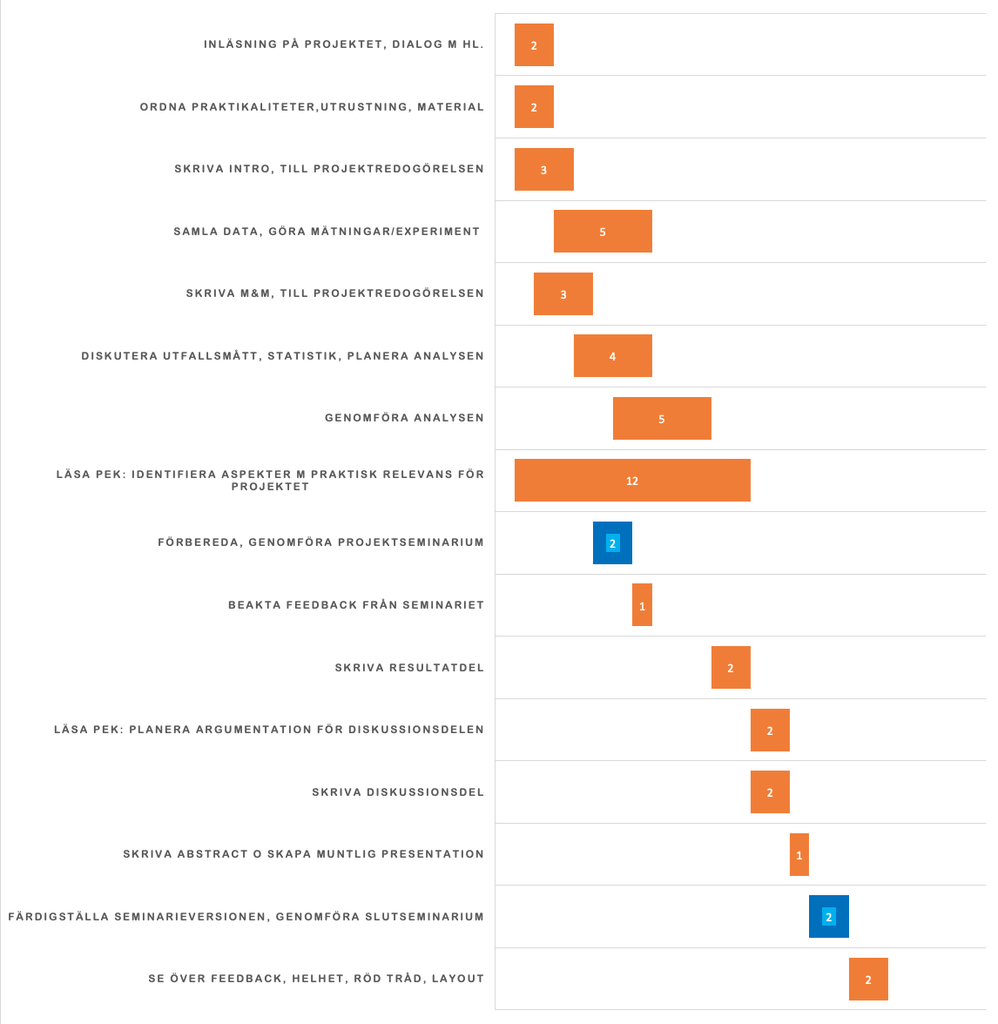

Gantt chart overview of the project timeline.

# References

1.

Gerdin M. The risk of dying: Predicting trauma mortality in urban indian hospitals. Stockholm: Karolinska Institutet; 2015.

2.

GBD 2019 Diseases and Injuries Collaborators. Injuries—level 1 cause. The Lancet. 2020 Oct;396.

3.

Organization WH. Guidelines for trauma quality improvement programmes. Available from https://apps.who.int/iris/handle/10665/44061 (2023/09/21);

4.

Santana MJ, Stelfox HT. Development and evaluation of evidence-informed quality indicators for adult injury care. Annals of Surgery [Internet]. 2014 Jan;259(1):186–92. Available from: https://doi.org/10.1097/sla.0b013e31828df98e

5.

McDermott FT. TRAUMA AUDIT AND QUALITY IMPROVEMENT. ANZ Journal of Surgery [Internet]. 1994 Mar;64(3):147–54. Available from: https://doi.org/10.1111%2Fj.1445-2197.1994.tb02168.x

6.

Lazzara EH, Salisbury M, Hughes AM, Rogers JE, King HB, Salas E. The morbidity and mortality conference: Opportunities for enhancing patient safety. Journal of Patient Safety [Internet]. 2020 Aug;18(1):e275–81. Available from: https://doi.org/10.1097/pts.0000000000000765

7.

Ghorbani P, Strömmer L. Analysis of preventable deaths and errors in trauma care in a scandinavian trauma level-i centre. Acta Anaesthesiologica Scandinavica [Internet]. 2018 May;62(8):1146–53. Available from: https://doi.org/10.1111/aas.13151

8.

Heim C, Cole E, West A, Tai N, Brohi K. Survival prediction algorithms miss significant opportunities for improvement if used for case selection in trauma quality improvement programs. Injury [Internet]. 2016 Sep;47(9):1960–5. Available from: https://doi.org/10.1016%2Fj.injury.2016.05.042

9.

Attergrim J, Szolnoky K. Predicting opportunities for improvement in trauma using machine learning: A registry based study. 2023 Jan; Available from: https://doi.org/10.1101/2023.01.19.23284654

10.

Organization WH. Injuries and violence: The facts 2014. Available at http:// https://iris.who.int/handle/10665/149798 (2005/06/12);

11.

Traumaregistret S. Årsrapporter. Available at https://rcsyd.se/swetrau/om-swetrau/arsrapporter (2023/09/21);